# Arrests

Boadiwaa

Created on March 23, 2022

### **Overview of Report**

The Arrests dataset is part of the carData package. The description from the official document accompanying the package reads: “Data on police treatment of individuals arrested in Toronto for simple possession of small quantities of marijuana. The data are part of a larger data set featured in a series of articles in the Toronto Star newspaper.” This report seeks to derive insights according to the following Objectives:

- Black vrs White Releases
- Yearly trend of arrests
- Employment status and its relation with Release status
- Age categories for arrests
- Female vrs Male Releases
- Citizen vrs Non-citizen Releases

### Glimpse of the Source Data

```r
#Gives an overview of the source data for this report.
test_data <- carData::Arrests
summary(test_data)
```

```
##  released     colour          year           age            sex
##  No : 892   Black:1288   Min.   :1997   Min.   :12.00   Female: 443
##  Yes:4334   White:3938   1st Qu.:1998   1st Qu.:18.00   Male  :4783
##                          Median :2000   Median :21.00
##                          Mean   :2000   Mean   :23.85
##                          3rd Qu.:2001   3rd Qu.:27.00
##                          Max.   :2002   Max.   :66.00
##  employed   citizen        checks
##  No :1115   No : 771   Min.   :0.000
##  Yes:4111   Yes:4455   1st Qu.:0.000
##                        Median :1.000
##                        Mean   :1.636
##                        3rd Qu.:3.000
##                        Max.   :6.000
```

```r
head(test_data)
```

```
##   released colour year age    sex employed citizen checks
## 1      Yes  White 2002  21   Male      Yes     Yes      3
## 2       No  Black 1999  17   Male      Yes     Yes      3
## 3      Yes  White 2000  24   Male      Yes     Yes      3
## 4       No  Black 2000  46   Male      Yes     Yes      1
## 5      Yes  Black 1999  27 Female      Yes     Yes      1
## 6      Yes  Black 1998  16 Female      Yes     Yes      0
```

### Did It Matter Whether They Were Black or White?

The graph below compares the statistics on arrests and releases according to the individual’s race (ie. Whether they were broadly-speaking: Black or White)

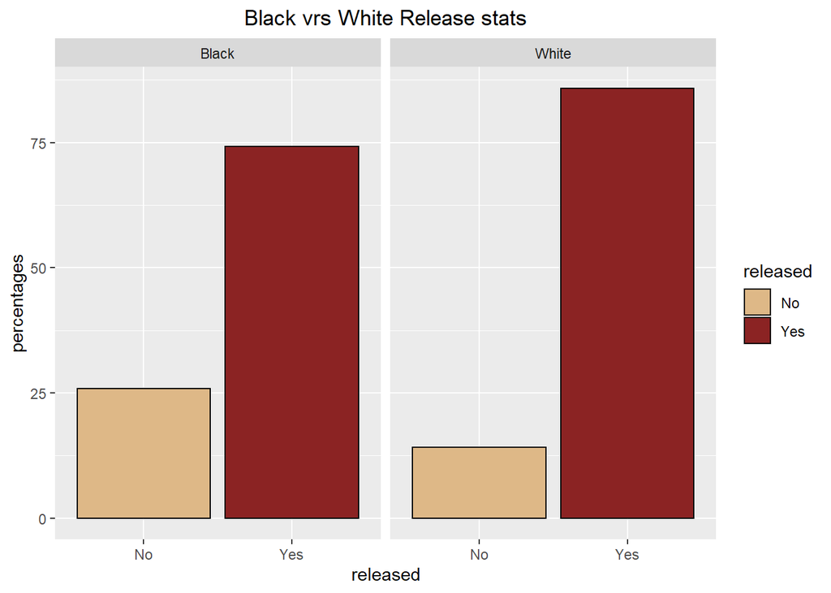

Figure1: Black vrs. White Statistics

### Yearly Trend of Arrests

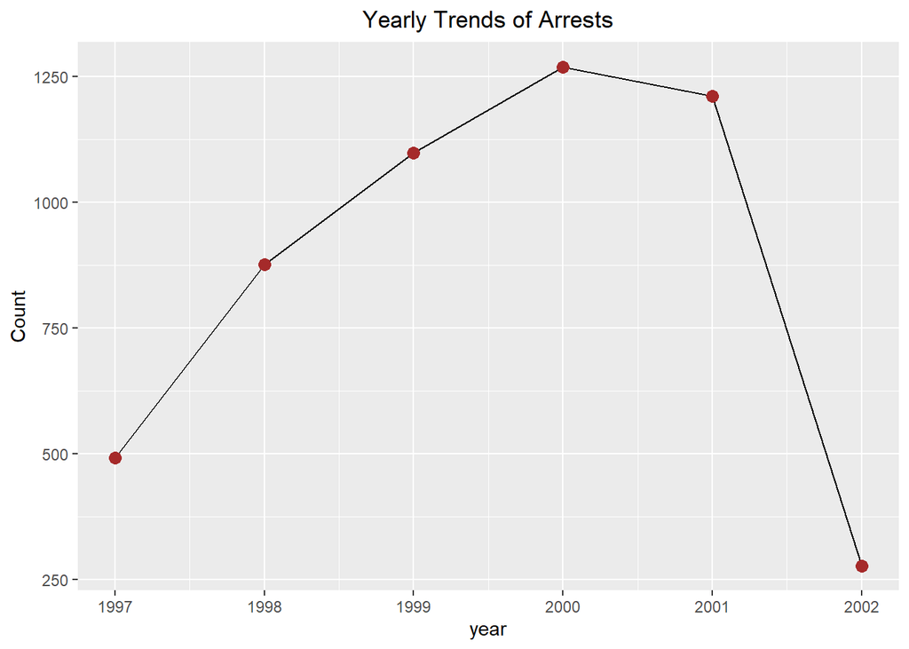

Figure 2: Trend of Number of Arrests over the years

### Employment status and its relation with Release status

The graph below shows that, majority of those who were released were in some form of employment. Overall, those who were employed were more than those who were not employed irrespective of the outcome of the arrests.

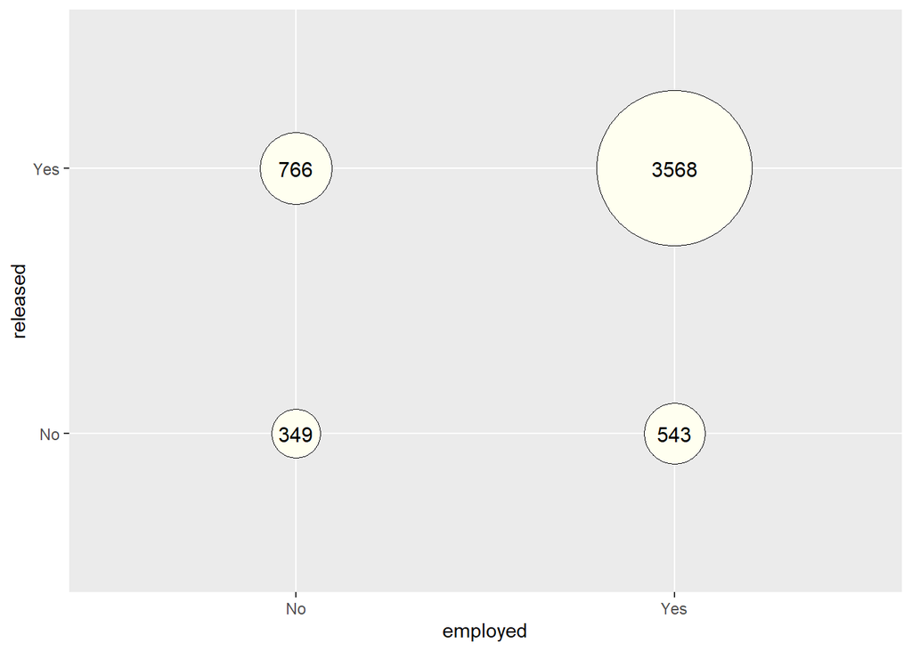

Figure 3: Employment Status in relation to Arrest Outcome

### Age Categories and Number of Arrests

Majority of arrests were made in the 18 to 29 age group. Here is a visualization of the data:

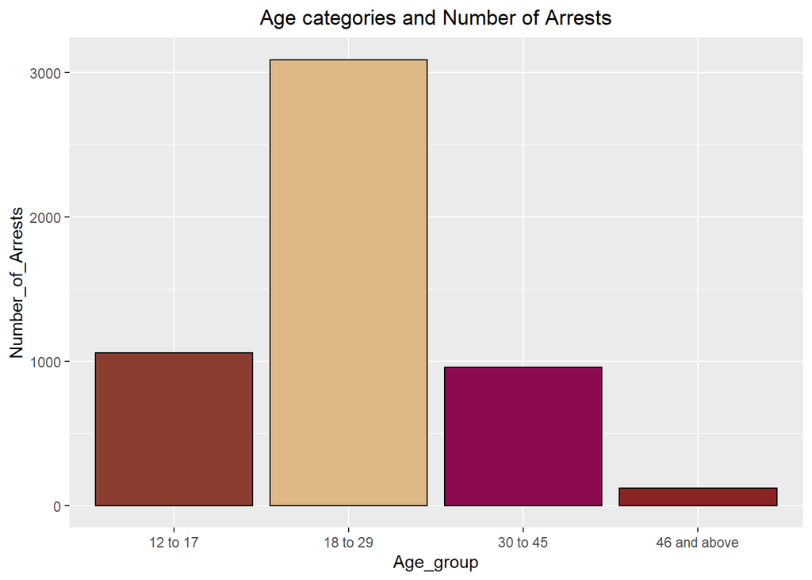

Figure 4: Age Categories vrs Arrests

### Stats of the Sexes

The table below shows the breakdown according to gender.

Table 1: Male Vrs. Female Arrests

| Gender | Number of Arrests |
| --- | --- |
| Female | 443 |
| Male | 4783 |

### Citizen Vrs Non-Citizen

The graph below compares the number of Citizens who were arrested and released, with the corresponding statistics in non-citizens:

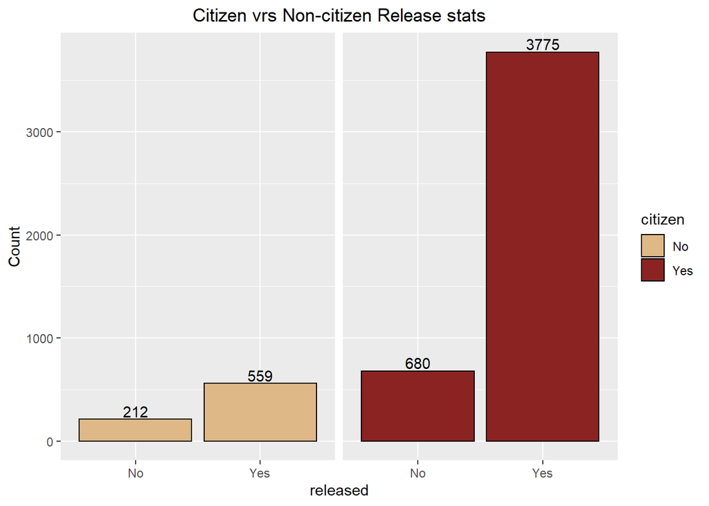

Figure 5: Citizens Vrs. Non-Citizens Release Stats

This brings us to the end of the brief report.

**Thank you!**